# Children use disagreement to infer what happened

Jamie Amemiya, Gail D. Heyman & Tobias Gerstenberg

April 09, 2024

# 1 Libraries

```r
library("lme4")        # for linear mixed effects models
library("rsample")     # for bootstrapping
library("xtable")      # for latex tables
library("kableExtra")  # for rmarkdown
library("knitr")       # for rmarkdown
library("car")         # for hypothesis test
library("Metrics")     # for rmse
library("scales")      # for percentage plots
library("broom.mixed") # for model summaries
library("grateful")    # for package citations
library("ggeffects")   # for marginal predictions
library("scales")      # for percentage scales
library("Hmisc")       # for bootstrapped means
library("ggtext")      # for colored text in ggplot
library("tidyverse")   # for everything else
```

# 2 Helper functions

```r
# set classic theme
theme_set(theme_classic() +
            theme(text = element_text(size = 16)))

# function for printing out html or latex tables
print_table = function(data, format = "html", digits = 2){
  if(format == "html"){
    data %>%
      kable(digits = digits) %>%
      kable_styling()
  }else if(format == "latex"){
    data %>%
      xtable(digits = digits,
             caption = "Caption",
             label = "tab:table") %>%
      print(include.rownames = F,
            booktabs = T,
            sanitize.colnames.function = identity,
            caption.placement = "top")
  }
}

# suppress grouping warning
options(dplyr.summarise.inform = F)

# show figures at the end of code chunks
opts_chunk$set(comment = "",
               fig.show = "hold")

# regression function
fun.regression = function(formula, data){
  results = glmer(formula = formula,
                  family = binomial,
                  data = data)
  print(results)
  return(results)
}

# results table
fun.table = function(results, type = "exploratory"){
  table = results %>%
    tidy(conf.int = T) %>%
    filter(effect == "fixed") %>%
    select(-group)

  if (type == "exploratory"){
    table = table %>%
      select(-c(p.value))
  }
  table %>%
    print_table()
}

# colors
l.color = list(agreement = "#89fa50",
               disagreement = "#ff968c",
               ambiguous = "#d38950",
               unambiguous = "#96d5d6")
```

# 3 EXPERIMENT 1

## 3.1 DATA

### 3.1.1 Read in data

```r
# fixed rounding issue; one participant was actually 11 and turned 12 the next day
# participant reported they were 9 despite birth year indicating they were 8;
# recoded to 9.69 given reported age likely more reliable

df.exp1 = read_csv("../data/data1_infer.csv") %>%
  rename(trial_order = trial_order_dada) %>%
  mutate(age_continuous = ifelse(age_continuous == 12, 11.99,
                          ifelse(age_continuous == 8.69, 9.69,
                                 age_continuous)))
```

## 3.2 STATS

### 3.2.1 Counterbalancing

- check if counterbalanced factors moderate the effect of trial type

#### 3.2.1.1 Story order

```r
results = fun.regression(
  formula = "ambiguous_yes ~ 1 + condition_disagree * story_order_wagon + (1 | participant)",
  data = df.exp1)
```

```
Generalized linear mixed model fit by maximum likelihood (Laplace
  Approximation) [glmerMod]
 Family: binomial  ( logit )
Formula: ambiguous_yes ~ 1 + condition_disagree * story_order_wagon +
    (1 | participant)
   Data: data
      AIC       BIC    logLik  deviance  df.resid
 243.5716  260.2593 -116.7858  233.5716       203
Random effects:
 Groups      Name        Std.Dev.
 participant (Intercept) 1.424
Number of obs: 208, groups:  participant, 52
Fixed Effects:
                         (Intercept)                    condition_disagree
                             -1.8473                                1.8559
                   story_order_wagon  condition_disagree:story_order_wagon
                              0.5618                               -0.2295
```

```r
fun.table(results)
```

| effect | term | estimate | std.error | statistic | conf.low | conf.high |
| --- | --- | --- | --- | --- | --- | --- |
| fixed | (Intercept) | -1.85 | 0.40 | -4.61 | -2.63 | -1.06 |
| fixed | condition_disagree | 1.86 | 0.42 | 4.46 | 1.04 | 2.67 |
| fixed | story_order_wagon | 0.56 | 0.36 | 1.56 | -0.15 | 1.27 |
| fixed | condition_disagree:story_order_wagon | -0.23 | 0.38 | -0.61 | -0.97 | 0.51 |

#### 3.2.1.2 Trial order

```r
results = fun.regression(
  formula = "ambiguous_yes ~ 1 + condition_disagree * trial_order + (1 | participant)",
  data = df.exp1)
```

```
Generalized linear mixed model fit by maximum likelihood (Laplace
  Approximation) [glmerMod]
 Family: binomial  ( logit )
Formula:
ambiguous_yes ~ 1 + condition_disagree * trial_order + (1 | participant)
   Data: data
      AIC       BIC    logLik  deviance  df.resid
 241.2821  257.9698 -115.6410  231.2821       203
Random effects:
 Groups      Name        Std.Dev.
 participant (Intercept) 1.477
Number of obs: 208, groups:  participant, 52
Fixed Effects:
                   (Intercept)              condition_disagree
                      -1.84349                         1.83408
                   trial_order  condition_disagree:trial_order
                      -0.02668                        -0.64759
```

```r
fun.table(results)
```

| effect | term | estimate | std.error | statistic | conf.low | conf.high |
| --- | --- | --- | --- | --- | --- | --- |
| fixed | (Intercept) | -1.84 | 0.40 | -4.57 | -2.63 | -1.05 |
| fixed | condition_disagree | 1.83 | 0.42 | 4.34 | 1.01 | 2.66 |
| fixed | trial_order | -0.03 | 0.35 | -0.08 | -0.72 | 0.67 |
| fixed | condition_disagree:trial_order | -0.65 | 0.39 | -1.67 | -1.41 | 0.11 |

#### 3.2.1.3 Valence

```r
results = fun.regression(
  formula = "ambiguous_yes ~ 1 + condition_disagree * valence_neg + (1 | participant)",
  data = df.exp1)
```

```
Generalized linear mixed model fit by maximum likelihood (Laplace
  Approximation) [glmerMod]
 Family: binomial  ( logit )
Formula:
ambiguous_yes ~ 1 + condition_disagree * valence_neg + (1 | participant)
   Data: data
      AIC       BIC    logLik  deviance  df.resid
 244.9991  261.6868 -117.4996  234.9991       203
Random effects:
 Groups      Name        Std.Dev.
 participant (Intercept) 1.481
Number of obs: 208, groups:  participant, 52
Fixed Effects:
                   (Intercept)              condition_disagree
                     -1.844699                        1.867938
                   valence_neg  condition_disagree:valence_neg
                     -0.004625                        0.350825
```

```r
fun.table(results)
```

| effect | term | estimate | std.error | statistic | conf.low | conf.high |
| --- | --- | --- | --- | --- | --- | --- |
| fixed | (Intercept) | -1.84 | 0.40 | -4.57 | -2.64 | -1.05 |
| fixed | condition_disagree | 1.87 | 0.42 | 4.44 | 1.04 | 2.69 |
| fixed | valence_neg | 0.00 | 0.36 | -0.01 | -0.70 | 0.69 |
| fixed | condition_disagree:valence_neg | 0.35 | 0.38 | 0.92 | -0.40 | 1.10 |

### 3.2.2 Confirmatory analysis

#### 3.2.2.1 Trial type effect

Choose ambiguous statement more in disagreement than agreement trials.

```r
results = fun.regression(
  formula = "ambiguous_yes ~ 1 + condition_disagree + (1 | participant)",
  data = df.exp1)
```

```
Generalized linear mixed model fit by maximum likelihood (Laplace
  Approximation) [glmerMod]
 Family: binomial  ( logit )
Formula: ambiguous_yes ~ 1 + condition_disagree + (1 | participant)
   Data: data
      AIC       BIC    logLik  deviance  df.resid
 242.4062  252.4188 -118.2031  236.4062       205
Random effects:
 Groups      Name        Std.Dev.
 participant (Intercept) 1.455
Number of obs: 208, groups:  participant, 52
Fixed Effects:
       (Intercept)  condition_disagree
            -1.828               1.828
```

```r
fun.table(results, type = "confirmatory")
```

| effect | term | estimate | std.error | statistic | p.value | conf.low | conf.high |
| --- | --- | --- | --- | --- | --- | --- | --- |
| fixed | (Intercept) | -1.83 | 0.40 | -4.62 | 0 | -2.60 | -1.05 |
| fixed | condition_disagree | 1.83 | 0.41 | 4.47 | 0 | 1.03 | 2.63 |

#### 3.2.2.2 Inferences above chance

Choose unambiguous in agreement trials above chance (log odds = -.69; 33%).

```r
results = fun.regression(
  formula = "unambiguous_yes ~ 1 + condition_disagree + (1 | participant)",
  data = df.exp1)
```

```
Generalized linear mixed model fit by maximum likelihood (Laplace
  Approximation) [glmerMod]
 Family: binomial  ( logit )
Formula: unambiguous_yes ~ 1 + condition_disagree + (1 | participant)
   Data: data
      AIC       BIC    logLik  deviance  df.resid
 242.1031  252.1157 -118.0515  236.1031       205
Random effects:
 Groups      Name        Std.Dev.
 participant (Intercept) 1.475
Number of obs: 208, groups:  participant, 52
Fixed Effects:
       (Intercept)  condition_disagree
             1.841              -1.893
```

```r
fun.table(results, type = "confirmatory")
```

| effect | term | estimate | std.error | statistic | p.value | conf.low | conf.high |
| --- | --- | --- | --- | --- | --- | --- | --- |
| fixed | (Intercept) | 1.84 | 0.40 | 4.61 | 0 | 1.06 | 2.62 |
| fixed | condition_disagree | -1.89 | 0.41 | -4.57 | 0 | -2.71 | -1.08 |

```r
linearHypothesis(results, "(Intercept) = -.69")
```

```
Linear hypothesis test

Hypothesis:
(Intercept) = - 0.69

Model 1: restricted model
Model 2: unambiguous_yes ~ 1 + condition_disagree + (1 | participant)

  Df  Chisq Pr(>Chisq)
1
2  1 40.144  2.359e-10 ***
---
Signif. codes:  0 '***' 0.001 '**' 0.01 '*' 0.05 '.' 0.1 ' ' 1
```

#### 3.2.2.3 Ambiguous choice

Choose ambiguous in disagreement trials above chance (log odds = -.69; 33%).

```r
results = fun.regression(
  formula = "ambiguous_yes ~ 1 + condition_agree + (1 | participant)",
  data = df.exp1)
```

```
Generalized linear mixed model fit by maximum likelihood (Laplace
  Approximation) [glmerMod]
 Family: binomial  ( logit )
Formula: ambiguous_yes ~ 1 + condition_agree + (1 | participant)
   Data: data
      AIC       BIC    logLik  deviance  df.resid
 242.4062  252.4188 -118.2031  236.4062       205
Random effects:
 Groups      Name        Std.Dev.
 participant (Intercept) 1.455
Number of obs: 208, groups:  participant, 52
Fixed Effects:
    (Intercept)  condition_agree
     -0.0003634       -1.8277981
```

```r
fun.table(results, type = "confirmatory")
```

| effect | term | estimate | std.error | statistic | p.value | conf.low | conf.high |
| --- | --- | --- | --- | --- | --- | --- | --- |
| fixed | (Intercept) | 0.00 | 0.31 | 0.00 | 1 | -0.61 | 0.61 |
| fixed | condition_agree | -1.83 | 0.41 | -4.47 | 0 | -2.63 | -1.03 |

```r
linearHypothesis(results, "(Intercept) = -.69")
```

```
Linear hypothesis test

Hypothesis:
(Intercept) = - 0.69

Model 1: restricted model
Model 2: ambiguous_yes ~ 1 + condition_agree + (1 | participant)

  Df  Chisq Pr(>Chisq)
1
2  1 4.8736    0.02727 *
---
Signif. codes:  0 '***' 0.001 '**' 0.01 '*' 0.05 '.' 0.1 ' ' 1
```

### 3.2.3 Exploratory analysis

#### 3.2.3.1 Trial type by age interaction

```r
results = fun.regression(
  formula = "ambiguous_yes ~ 1 + condition_disagree * age_continuous + (1 | participant)",
  data = df.exp1)
```

```
Generalized linear mixed model fit by maximum likelihood (Laplace
  Approximation) [glmerMod]
 Family: binomial  ( logit )
Formula: ambiguous_yes ~ 1 + condition_disagree * age_continuous + (1 |
    participant)
   Data: data
      AIC       BIC    logLik  deviance  df.resid
 237.4681  254.1558 -113.7340  227.4681       203
Random effects:
 Groups      Name        Std.Dev.
 participant (Intercept) 1.546
Number of obs: 208, groups:  participant, 52
Fixed Effects:
                      (Intercept)                 condition_disagree
                           2.5127                            -6.0120
                   age_continuous  condition_disagree:age_continuous
                          -0.4749                             0.8474
```

```r
fun.table(results)
```

| effect | term | estimate | std.error | statistic | conf.low | conf.high |
| --- | --- | --- | --- | --- | --- | --- |
| fixed | (Intercept) | 2.51 | 2.55 | 0.98 | -2.49 | 7.52 |
| fixed | condition_disagree | -6.01 | 2.74 | -2.20 | -11.38 | -0.65 |
| fixed | age_continuous | -0.47 | 0.28 | -1.71 | -1.02 | 0.07 |
| fixed | condition_disagree:age_continuous | 0.85 | 0.30 | 2.83 | 0.26 | 1.43 |

#### 3.2.3.2 Moderation by age

```r
# from 7 to 11 years
for(i in 7:11){
  cat(str_c("Age = ", i, "\n\n"))
  results = fun.regression(
    formula = "ambiguous_yes ~ 1 + condition_disagree + (1 | participant)",
    data = df.exp1 %>%
      filter(age_group == i))
}
```

```
Age = 7

Generalized linear mixed model fit by maximum likelihood (Laplace
  Approximation) [glmerMod]
 Family: binomial  ( logit )
Formula: ambiguous_yes ~ 1 + condition_disagree + (1 | participant)
   Data: data
     AIC      BIC   logLik deviance df.resid
 50.2215  55.2881 -22.1107  44.2215       37
Random effects:
 Groups      Name        Std.Dev.
 participant (Intercept) 2.049
Number of obs: 40, groups:  participant, 10
Fixed Effects:
       (Intercept)  condition_disagree
            -1.879               1.489
Age = 8

Generalized linear mixed model fit by maximum likelihood (Laplace
  Approximation) [glmerMod]
 Family: binomial  ( logit )
Formula: ambiguous_yes ~ 1 + condition_disagree + (1 | participant)
   Data: data
     AIC      BIC   logLik deviance df.resid
 61.2404  66.8540 -27.6202  55.2404       45
Random effects:
 Groups      Name        Std.Dev.
 participant (Intercept) 1.994
Number of obs: 48, groups:  participant, 12
Fixed Effects:
       (Intercept)  condition_disagree
           -1.1496              0.5988
Age = 9

Generalized linear mixed model fit by maximum likelihood (Laplace
  Approximation) [glmerMod]
 Family: binomial  ( logit )
Formula: ambiguous_yes ~ 1 + condition_disagree + (1 | participant)
   Data: data
     AIC      BIC   logLik deviance df.resid
```

[output cut: 25 more lines]

```

Generalized linear mixed model fit by maximum likelihood (Laplace
  Approximation) [glmerMod]
 Family: binomial  ( logit )
Formula: ambiguous_yes ~ 1 + condition_disagree + (1 | participant)
   Data: data
     AIC      BIC   logLik deviance df.resid
 40.0251  45.0917 -17.0125  34.0251       37
Random effects:
 Groups      Name        Std.Dev.
 participant (Intercept) 1.543
Number of obs: 40, groups:  participant, 10
Fixed Effects:
       (Intercept)  condition_disagree
            -2.956               4.529
```

## 3.3 PLOTS

### 3.3.1 Inference

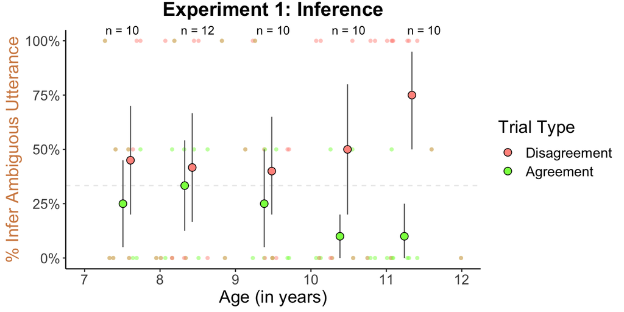

```r
set.seed(1)

df.plot.individual = df.exp1 %>%
    mutate(condition_disagree = as.character(condition_disagree)) %>%
    group_by(participant, age_continuous, condition_disagree) %>%
    summarize(pct_amb = sum(ambiguous_yes)/n())

df.age.means = df.plot.individual %>%
  distinct(participant, age_continuous) %>%
  mutate(age_group = floor(age_continuous)) %>%
  group_by(age_group) %>%
  summarize(age_mean = mean(age_continuous),
            n = str_c("n = ", n())) %>%
  ungroup()

df.plot.means = df.exp1 %>%
  mutate(condition_disagree = as.character(condition_disagree)) %>%
  group_by(participant, age_group, condition_disagree) %>%
  summarize(pct_amb = sum(ambiguous_yes)/n()) %>%
  group_by(age_group, condition_disagree) %>%
  reframe(response = smean.cl.boot(pct_amb),
          name = c("mean", "low", "high")) %>%
  left_join(df.age.means,
            by = "age_group") %>%
  pivot_wider(names_from = name,
              values_from = response) %>%
  mutate(age_mean = ifelse(condition_disagree == 0, age_mean - 0.05, age_mean + 0.05))

df.plot.text = df.plot.means %>%
  distinct(age_group, n)

ggplot() +
  geom_hline(yintercept = 1/3,
             linetype = 2,
             alpha = 0.1) +
  geom_point(data = df.plot.individual,
             mapping = aes(x = age_continuous,
                           y = pct_amb,
                           color = condition_disagree),
             alpha = 0.5,
             show.legend = T,
             shape = 16,
             size = 1.5) +
  geom_linerange(data = df.plot.means,
                 mapping = aes(x = age_mean,
                               y = mean,
                               ymin = low,
                               ymax = high),
                 color = "gray40") +
  geom_point(data = df.plot.means,
             mapping = aes(x = age_mean,
                           y = mean,
                           fill = condition_disagree),
             shape = 21,
             size = 3,
             show.legend = T) +
  geom_text(data = df.plot.text,
            mapping = aes(x = age_group + 0.5,
                          y = 1.05,
                          label = n),
            hjust = 0.5) +
  scale_y_continuous(labels = percent) +
  labs(x = "Age (in years)",
       y = "% Infer Ambiguous Utterance",
       title = "Experiment 1: Inference") +
  coord_cartesian(xlim = c(7, 12),
                  ylim = c(0, 1),
                  clip = "off") +
  scale_color_manual(name = "Trial Type",
                     labels = c("Agreement", "Disagreement"),
                     values = c(l.color$agreement, l.color$disagreement),
                     guide = guide_legend(reverse = T)) +
  scale_fill_manual(name = "Trial Type",
                    labels = c("Agreement", "Disagreement"),
                    values = c(l.color$agreement, l.color$disagreement),
                    guide = guide_legend(reverse = T)) +
  theme(plot.title = element_text(hjust = 0.5,
                                  vjust = 2,
                                  size = 18,
                                  face = "bold"),
        axis.title.y = element_markdown(color = l.color$ambiguous),
        legend.position = "right")

ggsave(filename = "../figures/plots/exp1_inference.pdf",
       width = 8,
       height = 4)
```

# 4 EXPERIMENT 2

## 4.1 DATA

### 4.1.1 Read in data

```r
df.exp2.predict = read_csv("../data/data2_predict.csv")
df.exp2.infer = read_csv("../data/data2_infer.csv") %>%
  drop_na()
```

## 4.2 STATS

### 4.2.1 Counterbalancing

#### 4.2.1.1 Prediction condition

##### 4.2.1.1.1 Story order

```r
results = fun.regression(
  formula = "dis_yes ~ 1 + condition_amb * story_order_wagon + (1 | participant)",
  data = df.exp2.predict)
```

```
Generalized linear mixed model fit by maximum likelihood (Laplace
  Approximation) [glmerMod]
 Family: binomial  ( logit )
Formula: dis_yes ~ 1 + condition_amb * story_order_wagon + (1 | participant)
   Data: data
      AIC       BIC    logLik  deviance  df.resid
 533.8373  554.1795 -261.9187  523.8373       427
Random effects:
 Groups      Name        Std.Dev.
 participant (Intercept) 0.5109
Number of obs: 432, groups:  participant, 54
Fixed Effects:
                    (Intercept)                    condition_amb
                        -1.2683                           1.5824
              story_order_wagon  condition_amb:story_order_wagon
                        -0.1105                           0.2620
```

```r
fun.table(results)
```

| effect | term | estimate | std.error | statistic | conf.low | conf.high |
| --- | --- | --- | --- | --- | --- | --- |
| fixed | (Intercept) | -1.27 | 0.19 | -6.85 | -1.63 | -0.91 |
| fixed | condition_amb | 1.58 | 0.23 | 7.00 | 1.14 | 2.03 |
| fixed | story_order_wagon | -0.11 | 0.18 | -0.62 | -0.46 | 0.24 |
| fixed | condition_amb:story_order_wagon | 0.26 | 0.22 | 1.20 | -0.17 | 0.69 |

##### 4.2.1.1.2 Trial order

```r
results = fun.regression(
  formula = "dis_yes ~ 1 + condition_amb*trial_order_auau + (1 | participant)",
  data = df.exp2.predict)
```

```
Generalized linear mixed model fit by maximum likelihood (Laplace
  Approximation) [glmerMod]
 Family: binomial  ( logit )
Formula: dis_yes ~ 1 + condition_amb * trial_order_auau + (1 | participant)
   Data: data
      AIC       BIC    logLik  deviance  df.resid
 533.6323  553.9745 -261.8162  523.6323       427
Random effects:
 Groups      Name        Std.Dev.
 participant (Intercept) 0.473
Number of obs: 432, groups:  participant, 54
Fixed Effects:
                   (Intercept)                   condition_amb
                      -1.25973                         1.58341
              trial_order_auau  condition_amb:trial_order_auau
                       0.15624                         0.01714
```

```r
fun.table(results)
```

| effect | term | estimate | std.error | statistic | conf.low | conf.high |
| --- | --- | --- | --- | --- | --- | --- |
| fixed | (Intercept) | -1.26 | 0.18 | -6.90 | -1.62 | -0.90 |
| fixed | condition_amb | 1.58 | 0.23 | 7.03 | 1.14 | 2.02 |
| fixed | trial_order_auau | 0.16 | 0.18 | 0.88 | -0.19 | 0.50 |
| fixed | condition_amb:trial_order_auau | 0.02 | 0.22 | 0.08 | -0.41 | 0.44 |

##### 4.2.1.1.3 Valence

```r
results = fun.regression(
  formula = "dis_yes ~ 1 + condition_amb * valence_neg + (1 | participant)",
  data = df.exp2.predict)
```

```
Generalized linear mixed model fit by maximum likelihood (Laplace
  Approximation) [glmerMod]
 Family: binomial  ( logit )
Formula: dis_yes ~ 1 + condition_amb * valence_neg + (1 | participant)
   Data: data
      AIC       BIC    logLik  deviance  df.resid
 531.5686  551.9108 -260.7843  521.5686       427
Random effects:
 Groups      Name        Std.Dev.
 participant (Intercept) 0.4787
Number of obs: 432, groups:  participant, 54
Fixed Effects:
              (Intercept)              condition_amb
                 -1.26341                    1.59408
              valence_neg  condition_amb:valence_neg
                 -0.05144                    0.34376
```

```r
fun.table(results)
```

| effect | term | estimate | std.error | statistic | conf.low | conf.high |
| --- | --- | --- | --- | --- | --- | --- |
| fixed | (Intercept) | -1.26 | 0.18 | -6.92 | -1.62 | -0.91 |
| fixed | condition_amb | 1.59 | 0.23 | 7.08 | 1.15 | 2.04 |
| fixed | valence_neg | -0.05 | 0.18 | -0.29 | -0.40 | 0.30 |
| fixed | condition_amb:valence_neg | 0.34 | 0.22 | 1.57 | -0.08 | 0.77 |

#### 4.2.1.2 Inference condition

##### 4.2.1.2.1 Story order

```r
results = fun.regression(
  formula = "ambiguous_yes ~ 1 + condition_disagree * story_order_wagon + (1 | participant)",
  data = df.exp2.infer)
```

```
Generalized linear mixed model fit by maximum likelihood (Laplace
  Approximation) [glmerMod]
 Family: binomial  ( logit )
Formula: ambiguous_yes ~ 1 + condition_disagree * story_order_wagon +
    (1 | participant)
   Data: data
      AIC       BIC    logLik  deviance  df.resid
 398.6856  419.1984 -194.3428  388.6856       442
Random effects:
 Groups      Name        Std.Dev.
 participant (Intercept) 1.009
Number of obs: 447, groups:  participant, 56
Fixed Effects:
                         (Intercept)                    condition_disagree
                           -2.687817                              3.783142
                   story_order_wagon  condition_disagree:story_order_wagon
                            0.005322                             -0.262981
```

```r
fun.table(results)
```

| effect | term | estimate | std.error | statistic | conf.low | conf.high |
| --- | --- | --- | --- | --- | --- | --- |
| fixed | (Intercept) | -2.69 | 0.31 | -8.70 | -3.29 | -2.08 |
| fixed | condition_disagree | 3.78 | 0.35 | 10.69 | 3.09 | 4.48 |
| fixed | story_order_wagon | 0.01 | 0.28 | 0.02 | -0.55 | 0.56 |
| fixed | condition_disagree:story_order_wagon | -0.26 | 0.31 | -0.86 | -0.86 | 0.33 |

##### 4.2.1.2.2 Trial order

```r
results = fun.regression(
  formula = "ambiguous_yes ~ 1 + condition_disagree * trial_order_dada + (1 | participant)",
  data = df.exp2.infer)
```

```
Generalized linear mixed model fit by maximum likelihood (Laplace
  Approximation) [glmerMod]
 Family: binomial  ( logit )
Formula: ambiguous_yes ~ 1 + condition_disagree * trial_order_dada + (1 |
    participant)
   Data: data
      AIC       BIC    logLik  deviance  df.resid
 400.1794  420.6922 -195.0897  390.1794       442
Random effects:
 Groups      Name        Std.Dev.
 participant (Intercept) 1.032
Number of obs: 447, groups:  participant, 56
Fixed Effects:
                        (Intercept)                   condition_disagree
                           -2.70545                              3.78219
                   trial_order_dada  condition_disagree:trial_order_dada
                           -0.06539                              0.08335
```

```r
fun.table(results)
```

| effect | term | estimate | std.error | statistic | conf.low | conf.high |
| --- | --- | --- | --- | --- | --- | --- |
| fixed | (Intercept) | -2.71 | 0.31 | -8.67 | -3.32 | -2.09 |
| fixed | condition_disagree | 3.78 | 0.36 | 10.62 | 3.08 | 4.48 |
| fixed | trial_order_dada | -0.07 | 0.29 | -0.23 | -0.63 | 0.49 |
| fixed | condition_disagree:trial_order_dada | 0.08 | 0.31 | 0.27 | -0.52 | 0.68 |

##### 4.2.1.2.3 Valence

```r
results = fun.regression(
  formula = "ambiguous_yes ~ 1 + condition_disagree * valence_neg + (1 | participant)",
  data = df.exp2.infer)
```

```
Generalized linear mixed model fit by maximum likelihood (Laplace
  Approximation) [glmerMod]
 Family: binomial  ( logit )
Formula:
ambiguous_yes ~ 1 + condition_disagree * valence_neg + (1 | participant)
   Data: data
      AIC       BIC    logLik  deviance  df.resid
 396.7389  417.2517 -193.3695  386.7389       442
Random effects:
 Groups      Name        Std.Dev.
 participant (Intercept) 0.9986
Number of obs: 447, groups:  participant, 56
Fixed Effects:
                   (Intercept)              condition_disagree
                       -2.6816                          3.7756
                   valence_neg  condition_disagree:valence_neg
                       -0.0941                         -0.3050
```

```r
fun.table(results)
```

| effect | term | estimate | std.error | statistic | conf.low | conf.high |
| --- | --- | --- | --- | --- | --- | --- |
| fixed | (Intercept) | -2.68 | 0.31 | -8.73 | -3.28 | -2.08 |
| fixed | condition_disagree | 3.78 | 0.35 | 10.65 | 3.08 | 4.47 |
| fixed | valence_neg | -0.09 | 0.28 | -0.33 | -0.65 | 0.46 |
| fixed | condition_disagree:valence_neg | -0.31 | 0.31 | -0.99 | -0.91 | 0.30 |

### 4.2.2 Confirmatory analyses

#### 4.2.2.1 Trial type effect

##### 4.2.2.1.1 Prediction condition

Predict disagreement more in ambiguous than unambiguous trials.

```r
results = fun.regression(
  formula = "dis_yes ~ 1 + condition_amb + (1 | participant)",
  data = df.exp2.predict)
```

```
Generalized linear mixed model fit by maximum likelihood (Laplace
  Approximation) [glmerMod]
 Family: binomial  ( logit )
Formula: dis_yes ~ 1 + condition_amb + (1 | participant)
   Data: data
      AIC       BIC    logLik  deviance  df.resid
 531.3732  543.5785 -262.6866  525.3732       429
Random effects:
 Groups      Name        Std.Dev.
 participant (Intercept) 0.5009
Number of obs: 432, groups:  participant, 54
Fixed Effects:
  (Intercept)  condition_amb
       -1.267          1.584
```

```r
prop.table(table(df.exp2.predict$condition_amb, df.exp2.predict$dis_yes),
           margin = 1)
```

```
            0         1
  0 0.7685185 0.2314815
  1 0.4259259 0.5740741
```

```r
fun.table(results, type = "confirmatory")
```

| effect | term | estimate | std.error | statistic | p.value | conf.low | conf.high |
| --- | --- | --- | --- | --- | --- | --- | --- |
| fixed | (Intercept) | -1.27 | 0.18 | -6.88 | 0 | -1.63 | -0.91 |
| fixed | condition_amb | 1.58 | 0.23 | 7.03 | 0 | 1.14 | 2.02 |

##### 4.2.2.1.2 Inference condition

Choose ambiguous statement more in disagreement than agreement trials.

```r
results = fun.regression(
  formula = "ambiguous_yes ~ 1 + condition_disagree + (1 | participant)",
  data = df.exp2.infer)
```

```
Generalized linear mixed model fit by maximum likelihood (Laplace
  Approximation) [glmerMod]
 Family: binomial  ( logit )
Formula: ambiguous_yes ~ 1 + condition_disagree + (1 | participant)
   Data: data
      AIC       BIC    logLik  deviance  df.resid
 396.2555  408.5632 -195.1278  390.2555       444
Random effects:
 Groups      Name        Std.Dev.
 participant (Intercept) 1.028
Number of obs: 447, groups:  participant, 56
Fixed Effects:
       (Intercept)  condition_disagree
            -2.697               3.771
```

```r
prop.table(table(df.exp2.infer$condition_disagree, df.exp2.infer$ambiguous_yes),
           margin = 1)
```

```
             0          1
  0 0.91071429 0.08928571
  1 0.29147982 0.70852018
```

```r
fun.table(results, type = "confirmatory")
```

| effect | term | estimate | std.error | statistic | p.value | conf.low | conf.high |
| --- | --- | --- | --- | --- | --- | --- | --- |
| fixed | (Intercept) | -2.70 | 0.31 | -8.72 | 0 | -3.30 | -2.09 |
| fixed | condition_disagree | 3.77 | 0.35 | 10.69 | 0 | 3.08 | 4.46 |

### 4.2.3 Exploratory analysis

#### 4.2.3.1 Trial type by age interaction

##### 4.2.3.1.1 Prediction

```r
results = fun.regression(
  formula = "dis_yes ~ 1 + condition_amb * age_continuous + (1 | participant)",
  data = df.exp2.predict)
```

```
Generalized linear mixed model fit by maximum likelihood (Laplace
  Approximation) [glmerMod]
 Family: binomial  ( logit )
Formula: dis_yes ~ 1 + condition_amb * age_continuous + (1 | participant)
   Data: data
      AIC       BIC    logLik  deviance  df.resid
 533.1134  553.4555 -261.5567  523.1134       427
Random effects:
 Groups      Name        Std.Dev.
 participant (Intercept) 0.4888
Number of obs: 432, groups:  participant, 54
Fixed Effects:
                 (Intercept)                 condition_amb
                      0.3225                       -0.3813
              age_continuous  condition_amb:age_continuous
                     -0.1702                        0.2100
```

```r
fun.table(results)
```

| effect | term | estimate | std.error | statistic | conf.low | conf.high |
| --- | --- | --- | --- | --- | --- | --- |
| fixed | (Intercept) | 0.32 | 1.16 | 0.28 | -1.95 | 2.60 |
| fixed | condition_amb | -0.38 | 1.43 | -0.27 | -3.18 | 2.41 |
| fixed | age_continuous | -0.17 | 0.12 | -1.37 | -0.41 | 0.07 |
| fixed | condition_amb:age_continuous | 0.21 | 0.15 | 1.39 | -0.09 | 0.51 |

##### 4.2.3.1.2 Inference

```r
results = fun.regression(
  formula = "ambiguous_yes ~ 1 + condition_disagree * age_continuous + (1 | participant)",
  data = df.exp2.infer)
```

```
Generalized linear mixed model fit by maximum likelihood (Laplace
  Approximation) [glmerMod]
 Family: binomial  ( logit )
Formula: ambiguous_yes ~ 1 + condition_disagree * age_continuous + (1 |
    participant)
   Data: data
      AIC       BIC    logLik  deviance  df.resid
 370.9069  391.4197 -180.4534  360.9069       442
Random effects:
 Groups      Name        Std.Dev.
 participant (Intercept) 1.188
Number of obs: 447, groups:  participant, 56
Fixed Effects:
                      (Intercept)                 condition_disagree
                           4.0689                            -7.5859
                   age_continuous  condition_disagree:age_continuous
                          -0.7699                             1.2725
```

```r
fun.table(results)
```

| effect | term | estimate | std.error | statistic | conf.low | conf.high |
| --- | --- | --- | --- | --- | --- | --- |
| fixed | (Intercept) | 4.07 | 2.20 | 1.85 | -0.24 | 8.38 |
| fixed | condition_disagree | -7.59 | 2.30 | -3.30 | -12.09 | -3.08 |
| fixed | age_continuous | -0.77 | 0.25 | -3.05 | -1.26 | -0.27 |
| fixed | condition_disagree:age_continuous | 1.27 | 0.27 | 4.70 | 0.74 | 1.80 |

#### 4.2.3.2 Moderation by age

##### 4.2.3.2.1 Prediction condition

```r
# from 7 to 11 years
for(i in 7:11){
  cat(str_c("Age = ", i, "\n\n"))
  fun.regression(
    formula = "dis_yes ~ 1 + condition_amb + (1 | participant)",
    data = df.exp2.predict %>%
      filter(age_group == i))
}
```

```
Age = 7

Generalized linear mixed model fit by maximum likelihood (Laplace
  Approximation) [glmerMod]
 Family: binomial  ( logit )
Formula: dis_yes ~ 1 + condition_amb + (1 | participant)
   Data: data
     AIC      BIC   logLik deviance df.resid
124.0071 131.7002 -59.0036 118.0071       93
Random effects:
 Groups      Name        Std.Dev.
 participant (Intercept) 1.161
Number of obs: 96, groups:  participant, 12
Fixed Effects:
  (Intercept)  condition_amb
      -0.9926         1.2093
Age = 8
```

```
boundary (singular) fit: see help('isSingular')
```

```
Generalized linear mixed model fit by maximum likelihood (Laplace
  Approximation) [glmerMod]
 Family: binomial  ( logit )
Formula: dis_yes ~ 1 + condition_amb + (1 | participant)
   Data: data
     AIC      BIC   logLik deviance df.resid
 93.6577 100.8037 -43.8288  87.6577       77
Random effects:
 Groups      Name        Std.Dev.
 participant (Intercept) 3.525e-08
Number of obs: 80, groups:  participant, 10
Fixed Effects:
  (Intercept)  condition_amb
       -1.735          2.140
optimizer (Nelder_Mead) convergence code: 0 (OK) ; 0 optimizer warnings; 1 lme4 warnings
Age = 9

Generalized linear mixed model fit by maximum likelihood (Laplace
  Approximation) [glmerMod]
 Family: binomial  ( logit )
Formula: dis_yes ~ 1 + condition_amb + (1 | participant)
   Data: data
     AIC      BIC   logLik deviance df.resid
130.8159 138.5089 -62.4079 124.8159       93
Random effects:
 Groups      Name        Std.Dev.
 participant (Intercept) 0.1557
Number of obs: 96, groups:  participant, 12
Fixed Effects:
  (Intercept)  condition_amb
       -0.793          1.132
Age = 10

Generalized linear mixed model fit by maximum likelihood (Laplace
  Approximation) [glmerMod]
 Family: binomial  ( logit )
Formula: dis_yes ~ 1 + condition_amb + (1 | participant)
   Data: data
     AIC      BIC   logLik deviance df.resid
 94.7171 101.8631 -44.3585  88.7171       77
Random effects:
 Groups      Name        Std.Dev.
 participant (Intercept) 0.3675
Number of obs: 80, groups:  participant, 10
Fixed Effects:
  (Intercept)  condition_amb
       -1.782          1.989
Age = 11
```

```
boundary (singular) fit: see help('isSingular')
```

```
Generalized linear mixed model fit by maximum likelihood (Laplace
  Approximation) [glmerMod]
 Family: binomial  ( logit )
Formula: dis_yes ~ 1 + condition_amb + (1 | participant)
   Data: data
     AIC      BIC   logLik deviance df.resid
 99.8731 107.0192 -46.9366  93.8731       77
Random effects:
 Groups      Name        Std.Dev.
 participant (Intercept) 1.804e-07
Number of obs: 80, groups:  participant, 10
Fixed Effects:
  (Intercept)  condition_amb
       -1.386          1.792
optimizer (Nelder_Mead) convergence code: 0 (OK) ; 0 optimizer warnings; 1 lme4 warnings
```

##### 4.2.3.2.2 Inference condition

```r
# from 7 to 11 years
for(i in 7:11){
  cat(str_c("Age = ", i, "\n\n"))
  fun.regression(
    formula = "ambiguous_yes ~ 1 + condition_disagree + (1 | participant)",
    data = df.exp2.infer %>%
      filter(age_group == i))
}
```

```
Age = 7

Generalized linear mixed model fit by maximum likelihood (Laplace
  Approximation) [glmerMod]
 Family: binomial  ( logit )
Formula: ambiguous_yes ~ 1 + condition_disagree + (1 | participant)
   Data: data
     AIC      BIC   logLik deviance df.resid
120.7673 128.4603 -57.3836 114.7673       93
Random effects:
 Groups      Name        Std.Dev.
 participant (Intercept) 0.8776
Number of obs: 96, groups:  participant, 12
Fixed Effects:
       (Intercept)  condition_disagree
            -1.410               1.197
Age = 8

Generalized linear mixed model fit by maximum likelihood (Laplace
  Approximation) [glmerMod]
 Family: binomial  ( logit )
Formula: ambiguous_yes ~ 1 + condition_disagree + (1 | participant)
   Data: data
     AIC      BIC   logLik deviance df.resid
  88.856   96.549  -41.428   82.856       93
Random effects:
 Groups      Name        Std.Dev.
 participant (Intercept) 1.184
Number of obs: 96, groups:  participant, 12
Fixed Effects:
       (Intercept)  condition_disagree
            -2.911               3.917
Age = 9

Generalized linear mixed model fit by maximum likelihood (Laplace
  Approximation) [glmerMod]
 Family: binomial  ( logit )
Formula: ambiguous_yes ~ 1 + condition_disagree + (1 | participant)
   Data: data
     AIC      BIC   logLik deviance df.resid
 52.2821  59.9752 -23.1411  46.2821       93
Random effects:
 Groups      Name        Std.Dev.
 participant (Intercept) 3.168
Number of obs: 96, groups:  participant, 12
Fixed Effects:
       (Intercept)  condition_disagree
            -5.704               8.442
Age = 10
```

```
boundary (singular) fit: see help('isSingular')
```

```
Generalized linear mixed model fit by maximum likelihood (Laplace
  Approximation) [glmerMod]
 Family: binomial  ( logit )
Formula: ambiguous_yes ~ 1 + condition_disagree + (1 | participant)
   Data: data
     AIC      BIC   logLik deviance df.resid
 43.0340  50.1423 -18.5170  37.0340       76
Random effects:
 Groups      Name        Std.Dev.
 participant (Intercept) 0
Number of obs: 79, groups:  participant, 10
Fixed Effects:
       (Intercept)  condition_disagree
            -2.944               5.429
optimizer (Nelder_Mead) convergence code: 0 (OK) ; 0 optimizer warnings; 1 lme4 warnings
Age = 11

Generalized linear mixed model fit by maximum likelihood (Laplace
  Approximation) [glmerMod]
 Family: binomial  ( logit )
Formula: ambiguous_yes ~ 1 + condition_disagree + (1 | participant)
   Data: data
     AIC      BIC   logLik deviance df.resid
 65.8653  73.0114 -29.9327  59.8653       77
Random effects:
 Groups      Name        Std.Dev.
 participant (Intercept) 0.843
Number of obs: 80, groups:  participant, 10
Fixed Effects:
       (Intercept)  condition_disagree
            -3.241               4.510
```

##### 4.2.3.2.3 Inference condition: First story only

Examine story 1 (trials 1 and 2) and story 4 (trials 7 and 8) among 7-year-olds.

```r
# story 1, 7 year olds
df.exp2.infer.7.1 = df.exp2.infer %>%
  filter(age_group == 7 &
          (trial == "trial 1" |trial == "trial 2"))

results = fun.regression(
  formula = "ambiguous_yes ~ 1 + condition_disagree + (1 | participant)",
  data = df.exp2.infer.7.1)
```

```
boundary (singular) fit: see help('isSingular')
```

```
Generalized linear mixed model fit by maximum likelihood (Laplace
  Approximation) [glmerMod]
 Family: binomial  ( logit )
Formula: ambiguous_yes ~ 1 + condition_disagree + (1 | participant)
   Data: data
     AIC      BIC   logLik deviance df.resid
 34.7724  38.3065 -14.3862  28.7724       21
Random effects:
 Groups      Name        Std.Dev.
 participant (Intercept) 0
Number of obs: 24, groups:  participant, 12
Fixed Effects:
       (Intercept)  condition_disagree
           -0.6931             -0.4055
optimizer (Nelder_Mead) convergence code: 0 (OK) ; 0 optimizer warnings; 1 lme4 warnings
```

```r
prop.table(table(df.exp2.infer.7.1$condition_disagree, df.exp2.infer.7.1$ambiguous_yes),
           margin = 1)
```

```
            0         1
  0 0.6666667 0.3333333
  1 0.7500000 0.2500000
```

```r
fun.table(results, type = "confirmatory")
```

| effect | term | estimate | std.error | statistic | p.value | conf.low | conf.high |
| --- | --- | --- | --- | --- | --- | --- | --- |
| fixed | (Intercept) | -0.69 | 0.61 | -1.13 | 0.26 | -1.89 | 0.51 |
| fixed | condition_disagree | -0.41 | 0.91 | -0.45 | 0.65 | -2.18 | 1.37 |

```r
# story 4, 7 year olds
df.exp2.infer.7.4 = df.exp2.infer %>%
  filter(age_group == 7 &
          (trial == "trial 7" |trial == "trial 8"))

results = fun.regression(
  formula = "ambiguous_yes ~ 1 + condition_disagree + (1 | participant)",
  data = df.exp2.infer.7.4)
```

```
boundary (singular) fit: see help('isSingular')
```

```
Generalized linear mixed model fit by maximum likelihood (Laplace
  Approximation) [glmerMod]
 Family: binomial  ( logit )
Formula: ambiguous_yes ~ 1 + condition_disagree + (1 | participant)
   Data: data
     AIC      BIC   logLik deviance df.resid
 35.7967  39.3308 -14.8983  29.7967       21
Random effects:
 Groups      Name        Std.Dev.
 participant (Intercept) 0
Number of obs: 24, groups:  participant, 12
Fixed Effects:
       (Intercept)  condition_disagree
            -1.099               1.435
optimizer (Nelder_Mead) convergence code: 0 (OK) ; 0 optimizer warnings; 1 lme4 warnings
```

```r
prop.table(table(df.exp2.infer.7.4$condition_disagree, df.exp2.infer.7.4$ambiguous_yes),
           margin = 1)
```

```
            0         1
  0 0.7500000 0.2500000
  1 0.4166667 0.5833333
```

```r
fun.table(results, type = "confirmatory")
```

| effect | term | estimate | std.error | statistic | p.value | conf.low | conf.high |
| --- | --- | --- | --- | --- | --- | --- | --- |
| fixed | (Intercept) | -1.10 | 0.67 | -1.65 | 0.10 | -2.41 | 0.21 |
| fixed | condition_disagree | 1.44 | 0.89 | 1.62 | 0.11 | -0.30 | 3.17 |

### 4.2.4 Bayesian model

#### 4.2.4.1 Prediction data

```r
df.exp2.predict.prob = df.exp2.predict %>%
  count(age_group, condition_amb_c, dis_yes) %>%
  group_by(age_group, condition_amb_c) %>%
  mutate(probability = n/sum(n)) %>%
  ungroup() %>%
  mutate(utterance = str_remove_all(condition_amb_c, " Trials"),
         utterance = factor(utterance,
                            levels = c("Unambiguous", "Ambiguous")),
         agreement = factor(dis_yes,
                            levels = c(0, 1),
                            labels = c("agree", "disagree"))) %>%
  select(-c(condition_amb_c, dis_yes, n)) %>%
  relocate(probability, .after = last_col()) %>%
  arrange(age_group, utterance, agreement)
```

#### 4.2.4.2 Without softmax

```r
utterance_prior = c(0.5, 0.5)

df.inference = df.exp2.predict.prob %>%
    group_by(agreement, age_group) %>%
    mutate(prior = utterance_prior) %>%
    mutate(posterior = probability * prior /
               sum(probability * prior)) %>%
    ungroup()

df.model.posterior = df.inference %>%
    rename(condition = agreement) %>%
    mutate(condition = factor(condition,
                              levels = c("agree", "disagree"),
                              labels = c("Agreement Trials", "Disagreement Trials"))) %>%
    filter(utterance == "Ambiguous")
```

#### 4.2.4.3 One temperature parameter

```r
age = 7:11

softmax = function(vec, temp = 3) {
    out = exp(vec*temp) / sum(exp(vec*temp))
    return(out)
}

df.data = df.exp2.infer %>%
    count(age_group, condition_disagree_c, ambiguous_yes) %>%
    group_by(age_group, condition_disagree_c) %>%
    reframe(p = n/sum(n)) %>%
    filter(row_number() %% 2 == 0) %>%
    rename(agreement = condition_disagree_c) %>%
    mutate(agreement = ifelse(agreement == "Agreement Trials", "agree", "disagree"))

fit_softmax = function(beta){
    df.prediction = df.inference %>%
        filter(age_group %in% age) %>%
        select(age_group, utterance, agreement, posterior) %>%
        pivot_wider(names_from = utterance,
                    values_from = posterior) %>%
        rowwise() %>%
        mutate(Unambiguous_soft = softmax(c(Unambiguous, Ambiguous),
                                          temp = beta)[1],
               Ambiguous_soft = softmax(c(Unambiguous, Ambiguous),
                                        temp = beta)[2]) %>%
        select(age_group, agreement, prediction = Ambiguous_soft)

    # compute loss as squared error
    loss = df.data %>%
        filter(age_group %in% age) %>%
        left_join(df.prediction) %>%
        mutate(loss = (p-prediction)^2) %>%
        pull(loss) %>%
        sum()

    return(loss)
}

# find best fitting softmax parameter
fit = optim(par = 0,
            fn = fit_softmax)

# use the best parameter
beta = fit[[1]]

# model with softmax
df.model.softmax = df.inference %>%
    select(age_group, utterance, agreement, posterior) %>%
    pivot_wider(names_from = utterance,
                values_from = posterior) %>%
    rowwise() %>%
    mutate(Unambiguous_soft = softmax(c(Unambiguous, Ambiguous),
                                      temp = beta)[1],
           Ambiguous_soft = softmax(c(Unambiguous, Ambiguous),
                                    temp = beta)[2]) %>%
    select(age_group, condition = agreement, posterior = Ambiguous_soft) %>%
    mutate(condition = factor(condition,
                              levels = c("agree", "disagree"),
                              labels = c("Agreement Trials", "Disagreement Trials")))
```

#### 4.2.4.4 Linear increase of temperature parameter

- fit linear model of softmax temperature as a function of age

```r
# rm(beta)

fit_softmax_age = function(par){
  df.prediction = df.inference %>%
    select(age_group, utterance, agreement, posterior) %>%
    mutate(beta = par[1] + par[2] * age_group) %>%
    pivot_wider(names_from = utterance,
                values_from = posterior) %>%
    rowwise() %>%
    mutate(Unambiguous_soft = softmax(c(Unambiguous, Ambiguous),
                                      temp = beta)[1],
           Ambiguous_soft = softmax(c(Unambiguous, Ambiguous),
                                    temp = beta)[2]) %>%
    select(age_group, agreement, prediction = Ambiguous_soft)

  # compute loss as squared error
  loss = df.data %>%
    filter(age_group %in% age) %>%
    left_join(df.prediction,
              by = c("age_group", "agreement")) %>%
    mutate(loss = (p-prediction)^2) %>%
    pull(loss) %>%
    sum()

  return(loss)
}

# find best fitting softmax parameter
fit = optim(par = c(0, 0),
            fn = fit_softmax_age)

df.model.softmax.linear = df.inference %>%
    select(age_group, utterance, agreement, posterior) %>%
    pivot_wider(names_from = utterance,
                values_from = posterior) %>%
    mutate(beta = fit$par[1] + fit$par[2] * age_group) %>%
    rowwise() %>%
    mutate(Unambiguous_soft = softmax(c(Unambiguous, Ambiguous),
                                      temp = beta)[1],
           Ambiguous_soft = softmax(c(Unambiguous, Ambiguous),
                                    temp = beta)[2]) %>%
    select(age_group, condition = agreement, posterior = Ambiguous_soft) %>%
    mutate(condition = factor(condition,
                              levels = c("agree", "disagree"),
                              labels = c("Agreement Trials", "Disagreement Trials")))
```

#### 4.2.4.5 Model comparison

```r
df.model.posterior %>%
    mutate(name = "posterior") %>%
    select(-c(utterance, probability, prior)) %>%
    bind_rows(df.model.softmax %>%
                  mutate(name = "softmax")) %>%
    bind_rows(df.model.softmax.linear %>%
                  mutate(name = "softmax increase")) %>%
    pivot_wider(names_from = name,
                values_from = posterior) %>%
    left_join(df.data %>%
                  mutate(condition = factor(agreement,
                                            levels = c("agree", "disagree"),
                                            labels = c("Agreement Trials",
                                                       "Disagreement Trials"))) %>%
                  select(-agreement),
              by = c("age_group", "condition")) %>%
    summarize(
        r_posterior = cor(p, posterior),
        r_softmax = cor(p, softmax),
        r_softmaxincrease = cor(p, `softmax increase`),
        rmse_posterior = rmse(p, posterior),
        rmse_softmax = rmse(p, softmax),
        rmse_softmaxincrease = rmse(p, `softmax increase`)) %>%
    pivot_longer(cols = everything(),
                 names_to = c("index", "name"),
                 names_sep = "_") %>%
    pivot_wider(names_from = index,
                values_from = value) %>%
    print_table()
```

| name | r | rmse |
| --- | --- | --- |
| posterior | 0.96 | 0.21 |
| softmax | 0.96 | 0.17 |
| softmaxincrease | 0.98 | 0.15 |

## 4.3 PLOTS

### 4.3.1 Prediction

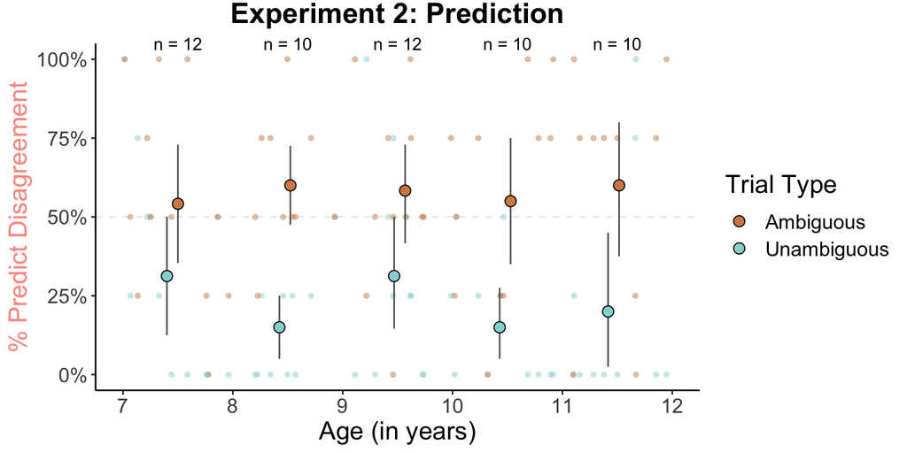

```r
set.seed(1)

df.plot.individual = df.exp2.predict %>%
    mutate(condition_amb = as.character(condition_amb)) %>%
    group_by(participant, age_continuous, condition_amb) %>%
    summarize(pct_dis = sum(dis_yes)/n())

df.age.means = df.plot.individual %>%
  distinct(participant, age_continuous) %>%
  mutate(age_group = floor(age_continuous)) %>%
  group_by(age_group) %>%
  summarize(age_mean = mean(age_continuous),
            n = str_c("n = ", n())) %>%
  ungroup()

df.plot.means = df.exp2.predict %>%
  mutate(condition_amb = as.character(condition_amb)) %>%
    group_by(participant, age_group, condition_amb) %>%
    summarize(pct_dis = sum(dis_yes)/n()) %>%
  group_by(age_group, condition_amb) %>%
  reframe(response = smean.cl.boot(pct_dis),
          name = c("mean", "low", "high")) %>%
  left_join(df.age.means,
            by = "age_group") %>%
  pivot_wider(names_from = name,
              values_from = response) %>%
  mutate(age_mean = ifelse(condition_amb == 0, age_mean - 0.05, age_mean + 0.05))

df.plot.text = df.plot.means %>%
  distinct(age_group, n)


ggplot() +
  geom_hline(yintercept = 0.5,
             linetype = 2,
             alpha = 0.1) +
  geom_point(data = df.plot.individual,
             mapping = aes(x = age_continuous,
                           y = pct_dis,
                           color = condition_amb),
             alpha = 0.5,
             show.legend = T,
             shape = 16,
             size = 1.5) +
  geom_linerange(data = df.plot.means,
                 mapping = aes(x = age_mean,
                               y = mean,
                               ymin = low,
                               ymax = high),
                 color = "gray40") +
  geom_point(data = df.plot.means,
             mapping = aes(x = age_mean,
                           y = mean,
                           fill = condition_amb),
             shape = 21,
             size = 3,
             show.legend = T) +
  geom_text(data = df.plot.text,
            mapping = aes(x = age_group + 0.5,
                          y = 1.05,
                          label = n),
            hjust = 0.5) +
  scale_y_continuous(labels = percent) +
  labs(x = "Age (in years)",
       y = "% Predict Disagreement",
       title = "Experiment 2: Prediction") +
  coord_cartesian(xlim = c(7, 12),
                  ylim = c(0, 1),
                  clip = "off") +
  scale_color_manual(name = "Trial Type",
                     labels = c("Unambiguous", "Ambiguous"),
                     values = c(l.color$unambiguous, l.color$ambiguous),
                     guide = guide_legend(reverse = T)) +
  scale_fill_manual(name = "Trial Type",
                    labels = c("Unambiguous", "Ambiguous"),
                    values = c(l.color$unambiguous, l.color$ambiguous),
                    guide = guide_legend(reverse = T)) +
  theme(plot.title = element_text(hjust = 0.5,
                                  vjust = 2,
                                  size = 18,
                                  face = "bold"),
        axis.title.y = element_markdown(color = l.color$disagreement),
        legend.position = "right")

ggsave(filename = "../figures/plots/exp2_prediction.pdf",
       width = 8,
       height = 4)
```

### 4.3.2 Inference

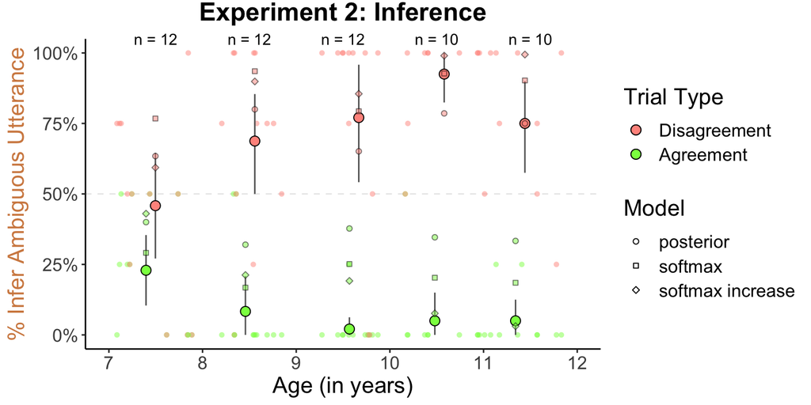

```r
set.seed(1)

df.plot.individual = df.exp2.infer %>%
    mutate(condition_disagree = as.character(condition_disagree)) %>%
    group_by(participant, age_continuous, condition_disagree) %>%
    summarize(pct_amb = sum(ambiguous_yes)/n())

df.age.means = df.plot.individual %>%
  distinct(participant, age_continuous) %>%
  mutate(age_group = floor(age_continuous)) %>%
  group_by(age_group) %>%
  summarize(age_mean = mean(age_continuous),
            n = str_c("n = ", n())) %>%
  ungroup()

df.plot.means = df.exp2.infer %>%
  mutate(condition_disagree = as.character(condition_disagree)) %>%
  group_by(participant, age_group, condition_disagree) %>%
  summarize(pct_amb = sum(ambiguous_yes)/n()) %>%
  group_by(age_group, condition_disagree) %>%
  reframe(response = smean.cl.boot(pct_amb),
          name = c("mean", "low", "high")) %>%
  left_join(df.age.means,
            by = "age_group") %>%
  pivot_wider(names_from = name,
              values_from = response) %>%
  mutate(age_mean = ifelse(condition_disagree == 0, age_mean - 0.05, age_mean + 0.05))

df.plot.text = df.plot.means %>%
  distinct(age_group, n)

df.model = df.model.posterior %>%
    mutate(name = "posterior") %>%
    select(-c(utterance, probability, prior)) %>%
    bind_rows(df.model.softmax %>%
                  mutate(name = "softmax")) %>%
    bind_rows(df.model.softmax.linear %>%
                  mutate(name = "softmax increase")) %>%
  mutate(condition_disagree = factor(condition,
                                     levels = c("Agreement Trials",
                                                "Disagreement Trials"),
                                     labels = c(0,
                                                1))) %>%
  left_join(df.age.means %>%
              select(-n),
            by = "age_group") %>%
  mutate(age_mean = ifelse(condition_disagree == 0,
                           age_mean - 0.05,
                           age_mean + 0.05))

ggplot() +
  geom_hline(yintercept = 0.5,
             linetype = 2,
             alpha = 0.1) +
  geom_point(data = df.plot.individual,
             mapping = aes(x = age_continuous,
                           y = pct_amb,
                           color = condition_disagree),
             alpha = 0.5,
             show.legend = T,
             shape = 16,
             size = 1.5) +
  geom_linerange(data = df.plot.means,
                 mapping = aes(x = age_mean,
                               y = mean,
                               ymin = low,
                               ymax = high),
                 color = "gray40",
                 show.legend = F) +
  geom_point(data = df.plot.means,
             mapping = aes(x = age_mean,
                           y = mean,
                           fill = condition_disagree),
             shape = 21,
             size = 3,
             show.legend = F) +
  geom_point(data = df.model,
             mapping = aes(x = age_mean,
                           y = posterior,
                           shape = name,
                           fill = condition_disagree),
             size = 1.5,
             alpha = 0.5,
             show.legend = T) +
    geom_text(data = df.plot.text,
            mapping = aes(x = age_group + 0.5,
                          y = 1.05,
                          label = n),
            hjust = 0.5) +
  scale_y_continuous(labels = percent) +
  labs(x = "Age (in years)",
       y = "% Infer Ambiguous Utterance",
       title = "Experiment 2: Inference") +
  coord_cartesian(xlim = c(7, 12),
                  ylim = c(0, 1),
                  clip = "off") +
  scale_color_manual(name = "Trial Type",
                     labels = c("Agreement", "Disagreement"),
                     values = c(l.color$agreement, l.color$disagreement)) +
  scale_fill_manual(name = "Trial Type",
                    labels = c("Agreement", "Disagreement"),
                    values = c(l.color$agreement, l.color$disagreement)) +
  scale_shape_manual(name = "Model",
                    labels = c("posterior", "softmax", "softmax increase"),
                    values = c(21, 22, 23)) +
  theme(plot.title = element_text(hjust = 0.5,
                                  vjust = 2,
                                  size = 18,
                                  face = "bold"),
        axis.title.y = element_markdown(color = l.color$ambiguous),
        legend.position = "right") +
  guides(fill = guide_legend(override.aes = list(shape = 21,
                                                 size = 3,
                                                 alpha = 1),
                             reverse = T,
                             order = 1),
         shape = guide_legend(override.aes = list(fill = "white",
                                                  alpha = 1)),
         color = "none")

ggsave(filename = "../figures/plots/exp2_inference.pdf",
       width = 8,
       height = 4)
```

# 5 Session info

```r
cite_packages(output = "paragraph",
              cite.tidyverse = TRUE,
              out.dir = ".")
```

We used R version 4.3.2 (R Core Team 2023) and the following R packages: bookdown v. 0.37 (Xie 2016, 2023a), broom.mixed v. 0.2.9.4 (Bolker and Robinson 2022), car v. 3.1.2 (Fox and Weisberg 2019), ggeffects v. 1.3.4 (Lüdecke 2018), ggtext v. 0.1.2 (Wilke and Wiernik 2022), Hmisc v. 5.1.1 (Harrell Jr 2023), kableExtra v. 1.3.4 (Zhu 2021), knitr v. 1.45 (Xie 2014, 2015, 2023b), lme4 v. 1.1.35.1 (Bates et al. 2015), Metrics v. 0.1.4 (Hamner and Frasco 2018), rmarkdown v. 2.25 (Xie, Allaire, and Grolemund 2018; Xie, Dervieux, and Riederer 2020; Allaire et al. 2023), rsample v. 1.2.0 (Frick et al. 2023), scales v. 1.3.0 (Wickham, Pedersen, and Seidel 2023), tidyverse v. 2.0.0 (Wickham et al. 2019), xtable v. 1.8.4 (Dahl et al. 2019).

Allaire, JJ, Yihui Xie, Christophe Dervieux, Jonathan McPherson, Javier Luraschi, Kevin Ushey, Aron Atkins, et al. 2023. *rmarkdown: Dynamic Documents for r*. https://github.com/rstudio/rmarkdown.

Bates, Douglas, Martin Mächler, Ben Bolker, and Steve Walker. 2015. “Fitting Linear Mixed-Effects Models Using lme4.” *Journal of Statistical Software* 67 (1): 1–48. https://doi.org/10.18637/jss.v067.i01.

Bolker, Ben, and David Robinson. 2022. *broom.mixed: Tidying Methods for Mixed Models*. https://CRAN.R-project.org/package=broom.mixed.

Dahl, David B., David Scott, Charles Roosen, Arni Magnusson, and Jonathan Swinton. 2019. *xtable: Export Tables to LaTeX or HTML*. https://CRAN.R-project.org/package=xtable.

Fox, John, and Sanford Weisberg. 2019. *An R Companion to Applied Regression*. Third. Thousand Oaks CA: Sage. https://socialsciences.mcmaster.ca/jfox/Books/Companion/.

Frick, Hannah, Fanny Chow, Max Kuhn, Michael Mahoney, Julia Silge, and Hadley Wickham. 2023. *rsample: General Resampling Infrastructure*. https://CRAN.R-project.org/package=rsample.

Hamner, Ben, and Michael Frasco. 2018. *Metrics: Evaluation Metrics for Machine Learning*. https://CRAN.R-project.org/package=Metrics.

Harrell Jr, Frank E. 2023. *Hmisc: Harrell Miscellaneous*. https://CRAN.R-project.org/package=Hmisc.

Lüdecke, Daniel. 2018. “ggeffects: Tidy Data Frames of Marginal Effects from Regression Models.” *Journal of Open Source Software* 3 (26): 772. https://doi.org/10.21105/joss.00772.

R Core Team. 2023. *R: A Language and Environment for Statistical Computing*. Vienna, Austria: R Foundation for Statistical Computing. https://www.R-project.org/.

Wickham, Hadley, Mara Averick, Jennifer Bryan, Winston Chang, Lucy D’Agostino McGowan, Romain François, Garrett Grolemund, et al. 2019. “Welcome to the tidyverse.” *Journal of Open Source Software* 4 (43): 1686. https://doi.org/10.21105/joss.01686.

Wickham, Hadley, Thomas Lin Pedersen, and Dana Seidel. 2023. *scales: Scale Functions for Visualization*. https://CRAN.R-project.org/package=scales.

Wilke, Claus O., and Brenton M. Wiernik. 2022. *ggtext: Improved Text Rendering Support for “ggplot2”*. https://CRAN.R-project.org/package=ggtext.

Xie, Yihui. 2014. “knitr: A Comprehensive Tool for Reproducible Research in R.” In *Implementing Reproducible Computational Research*, edited by Victoria Stodden, Friedrich Leisch, and Roger D. Peng. Chapman; Hall/CRC.

———. 2015. *Dynamic Documents with R and Knitr*. 2nd ed. Boca Raton, Florida: Chapman; Hall/CRC. https://yihui.org/knitr/.

———. 2016. *bookdown: Authoring Books and Technical Documents with R Markdown*. Boca Raton, Florida: Chapman; Hall/CRC. https://bookdown.org/yihui/bookdown.

———. 2023a. *bookdown: Authoring Books and Technical Documents with r Markdown*. https://github.com/rstudio/bookdown.

———. 2023b. *knitr: A General-Purpose Package for Dynamic Report Generation in r*. https://yihui.org/knitr/.

Xie, Yihui, J. J. Allaire, and Garrett Grolemund. 2018. *R Markdown: The Definitive Guide*. Boca Raton, Florida: Chapman; Hall/CRC. https://bookdown.org/yihui/rmarkdown.

Xie, Yihui, Christophe Dervieux, and Emily Riederer. 2020. *R Markdown Cookbook*. Boca Raton, Florida: Chapman; Hall/CRC. https://bookdown.org/yihui/rmarkdown-cookbook.

Zhu, Hao. 2021. *kableExtra: Construct Complex Table with “kable” and Pipe Syntax*. https://CRAN.R-project.org/package=kableExtra.